# Customer Purchase Behavior & Revenue Analysis

surekha

2026-02-04

## Business Problem

Retail leaders often struggle to identify the primary drivers of revenue and customer purchasing behavior despite having rich transactional data.

The objective of this analysis is to transform raw retail data into actionable insights that support strategic business decision-making.

## Data Preparation

```r
retail <- read_csv(here("data_raw","online_retail.csv"), show_col_types = FALSE)
```

```r
clean_retail <- retail %>%
  clean_names() %>%
  filter(!is.na(customer_id)) %>%
  filter(quantity > 0, unit_price > 0) %>%
  mutate(
    revenue = quantity * unit_price,
    month = floor_date(invoice_date, "month"),
    year = year(invoice_date)
  )
```

• This analysis evaluates $8.9M in transactional revenue to identify the behavioral and operational levers that most strongly influence business performance. • Average Order Value stands at **$480**, indicating strong basket sizes.  
• Revenue demonstrates strong seasonality, peaking during the holiday period.  
• Customer purchase frequency and basket size are the strongest drivers of revenue.

These insights highlight clear opportunities for revenue optimization through customer retention, basket expansion strategies, and seasonal demand planning.

```r
executive_kpi <- clean_retail %>%
  summarise(
    Total_Revenue = sum(revenue),
    Total_Orders = n_distinct(invoice_no),
    Total_Customers = n_distinct(customer_id),
    Avg_Order_Value = Total_Revenue / Total_Orders
  )

executive_kpi_fmt <- executive_kpi %>%
  mutate(
    Total_Revenue = dollar(Total_Revenue),
    Avg_Order_Value = dollar(Avg_Order_Value)
  )

kable(executive_kpi_fmt)
```

| Total_Revenue | Total_Orders | Total_Customers | Avg_Order_Value |
| --- | --- | --- | --- |
| $8,911,408 | 18532 | 4338 | $480.87 |

### Key Takeaway

The business generated substantial revenue across thousands of transactions, supported by a diverse customer base. Monitoring order value and customer purchasing behavior can help identify opportunities for revenue optimization.

## Revenue Trend Analysis

```r
monthly_revenue <- clean_retail %>%
  group_by(month) %>%
  summarise(
    revenue = sum(revenue),
    orders = n_distinct(invoice_no)
  )
```

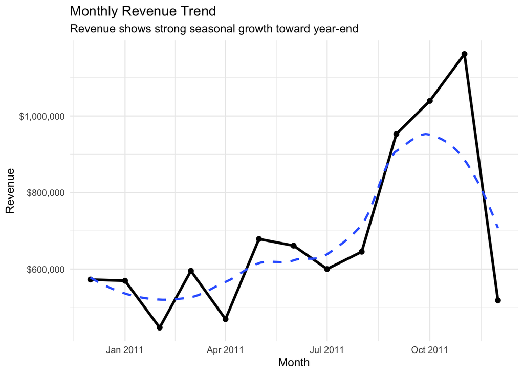

```r
ggplot(monthly_revenue, aes(x = month, y = revenue)) +
  geom_line(linewidth = 1.2) +
  geom_point(size = 2) +
  geom_smooth(se = FALSE, linetype = "dashed") +
  scale_y_continuous(labels = dollar) +
  labs(
    title = "Monthly Revenue Trend",
    subtitle = "Revenue shows strong seasonal growth toward year-end",
    x = "Month",
    y = "Revenue"
  )
```

### Business Insight

Revenue demonstrates a clear upward trajectory approaching the holiday season, indicating strong seasonal purchasing behavior.

This suggests that the business should proactively increase inventory, optimize marketing campaigns, and ensure operational readiness ahead of peak demand periods to maximize revenue.

## Revenue Drivers Analysis

```r
driver_data <- clean_retail %>%
  group_by(invoice_no) %>%
  summarise(
    order_value = sum(revenue),
    items_per_order = sum(quantity),
    unique_products = n_distinct(stock_code)
  )
```

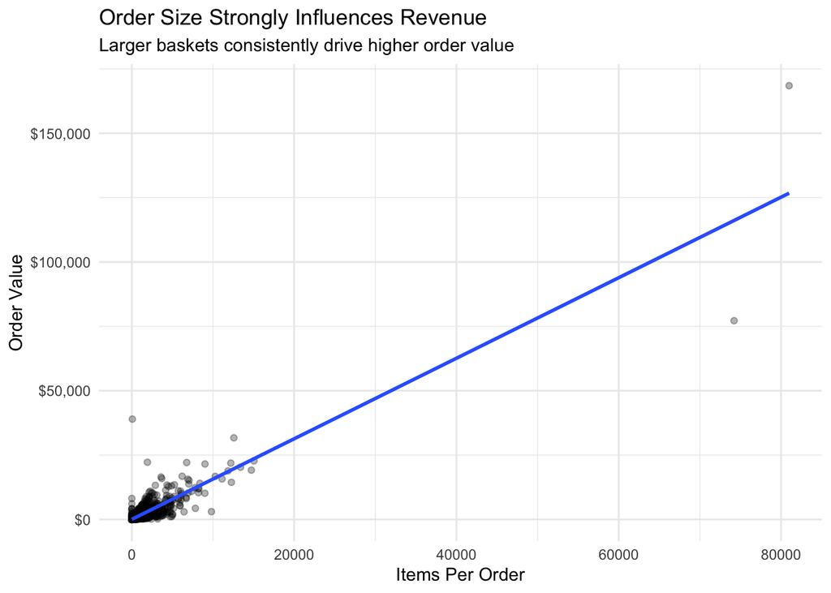

```r
ggplot(driver_data, aes(items_per_order, order_value)) +
  geom_point(alpha = 0.3) +
  geom_smooth(method = "lm", se = FALSE, linewidth = 1) +
  scale_y_continuous(labels = dollar) +
  labs(
    title = "Order Size Strongly Influences Revenue",
    subtitle = "Larger baskets consistently drive higher order value",
    x = "Items Per Order",
    y = "Order Value"
  )
```

### Business Insight

Order value increases significantly as the number of items per transaction rises, suggesting that basket expansion strategies such as product bundling, cross-selling, and volume discounts could materially improve revenue performance.

## Customer Segmentation (RFM Analysis)

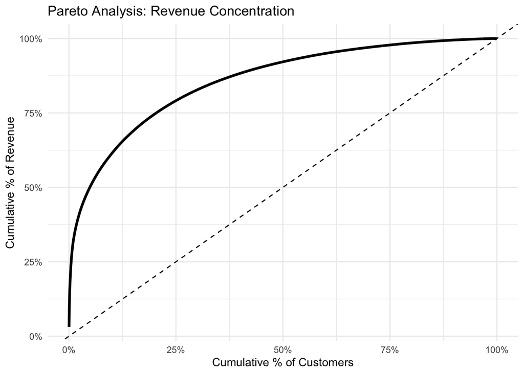

```r
ggplot(pareto, aes(customer_pct, revenue_pct)) +
  geom_line(linewidth = 1.2) +
  geom_abline(linetype = "dashed") +
  scale_y_continuous(labels = scales::percent) +
  scale_x_continuous(labels = scales::percent) +
  labs(
    title = "Pareto Analysis: Revenue Concentration",
    x = "Cumulative % of Customers",
    y = "Cumulative % of Revenue"
  )
```

The top 20% of customers contribute approximately 75% of total revenue, revealing a strong revenue concentration among high-value customers.

This highlights the importance of customer retention strategies, loyalty programs, and personalized marketing to protect and grow the business’s most valuable revenue segment.Losing a small portion of these customers could materially impact overall revenue performance.

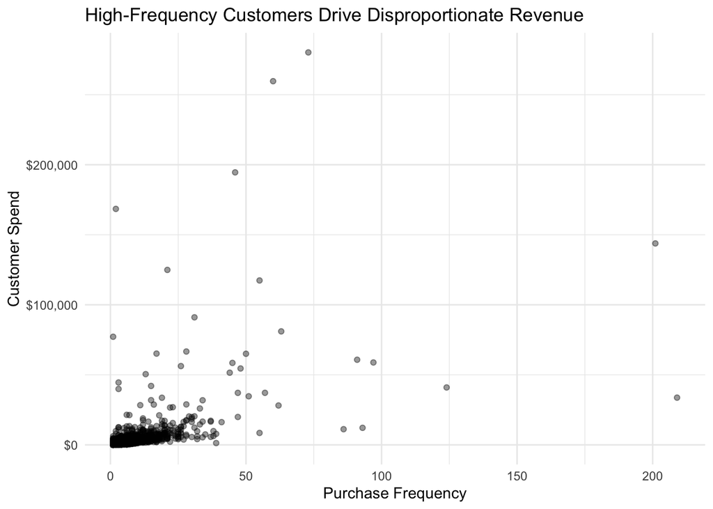

```r
ggplot(rfm, aes(frequency, monetary)) +
  geom_point(alpha = 0.4) +
  scale_y_continuous(labels = dollar) +
  labs(
    title = "High-Frequency Customers Drive Disproportionate Revenue",
    x = "Purchase Frequency",
    y = "Customer Spend"
  )
```

### Business Insight

A small segment of high-frequency customers contributes a disproportionately large share of total revenue. Prioritizing retention strategies for these customers could significantly enhance long-term profitability.

### Regression model

```r
model <- lm(order_value ~ items_per_order + unique_products, data = driver_data)

summary(model)
```

```
##
## Call:
## lm(formula = order_value ~ items_per_order + unique_products,
##     data = driver_data)
##
## Residuals:
##    Min     1Q Median     3Q    Max
## -38664    -73     -5     68  42041
##
## Coefficients:
##                  Estimate Std. Error t value             Pr(>|t|)
## (Intercept)     25.407978   6.976881   3.642             0.000272 ***
## items_per_order  1.560614   0.005403 288.852 < 0.0000000000000002 ***
## unique_products  0.968406   0.220666   4.389            0.0000115 ***
## ---
## Signif. codes:  0 '***' 0.001 '**' 0.01 '*' 0.05 '.' 0.1 ' ' 1
##
## Residual standard error: 708.1 on 18529 degrees of freedom
## Multiple R-squared:  0.822,  Adjusted R-squared:  0.8219
## F-statistic: 4.277e+04 on 2 and 18529 DF,  p-value: < 0.00000000000000022
```

### Business Interpretation

Each additional item added to an order increases order value by approximately $1.56, holding product variety constant.

This confirms that increasing basket size through cross-selling and bundled offers can directly and predictably improve revenue outcomes.

## Strategic Recommendations

Based on the analysis, the following actions are recommended:

1. Implement cross-sell and bundle strategies to increase average basket size.
2. Prioritize retention programs for high-frequency, high-spend customers.
3. Strengthen inventory and marketing preparedness ahead of peak seasonal demand.
4. Track order value and purchase frequency as core performance KPIs.

These initiatives are expected to drive sustainable revenue growth while improving customer lifetime value.